# The [Jupyter](http://jupyter.org/) Notebook

```python
import numpy as np
import pandas as pd
from pandas import Series, DataFrame

from IPython.display import HTML
from IPython.display import Image

import ipywidgets as widgets
from ipywidgets import interact, interactive, fixed
```

The Jupyter project provides a fairly language-agnostic analytic platform:

1. It currently supports over [40 languages](https://github.com/ipython/ipython/wiki/IPython-kernels-for-other-languages);
2. It easily shared (including HTML conversions for folks without the platform);
3. It features interactive [widgets](https://github.com/ipython/ipywidgets/blob/master/examples/notebooks/Widget%20Basics.ipynb);
4. It can capture a variety of media;
5. It can interact with the shell; and,
6. It provides instant documentation.

## Languages

"Kernel Zero" is the IPython kernel, and it's a basic dependency of the Notebook.

```python
np1000=np.random.uniform(size=1000)

np1000
```

[output not shown]

[output cut: 279 more lines]

[output not shown]

If speed is a concern, [Julia](https://github.com/choct155/work_scratch/blob/master/Julia_LinAlg.ipynb) is also quite useful. There are also kernel projects for [MATLAB](https://github.com/calysto/matlab_kernel) and [C++](https://github.com/minrk/clingkernel).

## Sharing

The Notebooks themselves are fairly lightweight [JSON](http://www.json.org/) files. They can be opened and edited by anyone who has Jupyter Notebook (and the language-appropriate kernel). The real gem for static formats, however, is [nbconvert](http://nbconvert.readthedocs.org/en/latest/). This functionality can convert dynamic Notebooks into static files in a number of formats, including the following:

1. Standalone HTML and Reveal.js slide decks (which can be opened by anyone with a browser);
2. LaTeX
3. PDF

## Embedding Media

We can grab and embed websites in an `iframe`, and even maintain javascript functionality.

```python
HTML('<iframe src=http://bl.ocks.org/mbostock/e1e1e7e2c360bec054ba width=1100 height=500></iframe>')
```

[interactive chart not shown]

Images can be generally displayed, whether they reside locally or on the web.

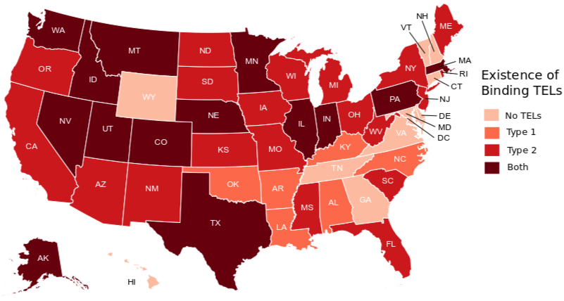

```python
Image('TEL_bind_states_lab.png')
```

## Interacting with Files

Not only do we have the full shell capability available from within the Notebook...

```python
!ls -lt
```

```
total 15838
-rwxr-xr-x  1 MarvinW        Domain Users   84706 Nov 23 10:26 Jupyter.ipynb
-rw-r--r--  1 MarvinW        Domain Users  119113 Nov 23 10:26 TEL_bind_states_lab.png
-rwxr-xr-x  1 MarvinW        Domain Users   83027 Nov 23 10:25 pandas_4_health.ipynb
-rwxr-xr-x  1 MarvinW        Domain Users 4871539 Nov 10 11:16 GeoSNAP.ipynb
-rwxr-xr-x  1 MarvinW        Domain Users      78 Nov  6 15:45 Untitled.ipynb
-rwxr-xr-x  1 MarvinW        Domain Users    5023 Nov  4 16:20 choro_map.py
-rwxr-xr-x  1 MarvinW        Domain Users   91129 Nov  4 15:08 GFS2013.ipynb
-rwxr-xr-x  1 MarvinW        Domain Users   49489 Oct 26 12:23 Gini.ipynb
-rw-r--r--  1 MarvinW        Domain Users  266172 Oct 20 08:19 Gini_coefficient.svg
-rwxr-xr-x  1 MarvinW        Domain Users    8507 Oct  2 14:34 pandas.jpg
drwxr-xr-x+ 1 MarvinW        Domain Users       0 Aug 21 12:12 modelingwithdata
-rwxr-xr-x  1 MarvinW        Domain Users  252312 Aug  3 16:28 SimulationConstruct.ipynb
-rwxr-xr-x  1 MarvinW        Domain Users  635271 Aug  3 11:21 QuantEcon_Markov.ipynb
-rwxr-xr-x  1 MarvinW        Domain Users   60407 Aug  3 11:19 notebook_d3.ipynb
-rwxr-xr-x  1 MarvinW        Domain Users   59785 Aug  3 10:51 embedding_interactive_charts_on_an_ipython_notebook.ipynb
-rwxr-xr-x  1 MarvinW        Domain Users   16203 Jul 30 14:28 Julia_LinAlg.ipynb
-rwxr-xr-x  1 MarvinW        Domain Users  418436 Jul 30 09:58 CensusPovThresh.ipynb
-rw-r--r--  1 MarvinW        Domain Users   28256 Jul 22 08:32 model_dump
-rwxr-xr-x  1 MarvinW        Domain Users   75359 Jul 22 08:32 ModelPermanence.ipynb
-rw-r--r--  1 MarvinW        Domain Users    7114 Jul 22 08:32 JuliaTypes.ipynb
-rwxr-xr-x  1 MarvinW        Domain Users  511710 Jul 17 12:21 WtAvg.ipynb
-rw-r--r--  1 MarvinW        Domain Users     153 Jul 17 12:08 README.md
-rwxrwx---+ 1 MarvinW        Domain Users   68272 Jul 10 11:15 QuantEcon_IntroExample.ipynb
-rwxrwx---+ 1 MarvinW        Domain Users   22861 May 19  2015 WeightedMedian.ipynb
-rwxrwx---+ 1 MarvinW        Domain Users   96693 May  5  2015 Interactions.ipynb
-rwxrwx---+ 1 MarvinW        Domain Users  145312 Mar 26  2015 MorgRefi.ipynb
-rwxrwx---+ 1 Administrators Domain Users 8124231 Jul 14  2014 PCA_residual_calc.ipynb
-rwxrwx---+ 1 Administrators Domain Users   29548 Jun 10  2014 Missing Data.ipynb
-rwxrwx---+ 1 MarvinW        Domain Users   27802 May 29  2014 fortranIntro.ipynb
```

...we can actively use the returns from these shell calls.

```python
files_in_cwd=!ls -lt

files_in_cwd
```

```
['total 16002',
 '-rwxr-xr-x  1 MarvinW        Domain Users  250264 Nov 23 10:28 Jupyter.ipynb',
 '-rw-r--r--  1 MarvinW        Domain Users  119113 Nov 23 10:26 TEL_bind_states_lab.png',
 '-rwxr-xr-x  1 MarvinW        Domain Users   83027 Nov 23 10:25 pandas_4_health.ipynb',
 '-rwxr-xr-x  1 MarvinW        Domain Users 4871539 Nov 10 11:16 GeoSNAP.ipynb',
 '-rwxr-xr-x  1 MarvinW        Domain Users      78 Nov  6 15:45 Untitled.ipynb',
 '-rwxr-xr-x  1 MarvinW        Domain Users    5023 Nov  4 16:20 choro_map.py',
 '-rwxr-xr-x  1 MarvinW        Domain Users   91129 Nov  4 15:08 GFS2013.ipynb',
 '-rwxr-xr-x  1 MarvinW        Domain Users   49489 Oct 26 12:23 Gini.ipynb',
 '-rw-r--r--  1 MarvinW        Domain Users  266172 Oct 20 08:19 Gini_coefficient.svg',
 '-rwxr-xr-x  1 MarvinW        Domain Users    8507 Oct  2 14:34 pandas.jpg',
 'drwxr-xr-x+ 1 MarvinW        Domain Users       0 Aug 21 12:12 modelingwithdata',
 '-rwxr-xr-x  1 MarvinW        Domain Users  252312 Aug  3 16:28 SimulationConstruct.ipynb',
 '-rwxr-xr-x  1 MarvinW        Domain Users  635271 Aug  3 11:21 QuantEcon_Markov.ipynb',
 '-rwxr-xr-x  1 MarvinW        Domain Users   60407 Aug  3 11:19 notebook_d3.ipynb',
 '-rwxr-xr-x  1 MarvinW        Domain Users   59785 Aug  3 10:51 embedding_interactive_charts_on_an_ipython_notebook.ipynb',
 '-rwxr-xr-x  1 MarvinW        Domain Users   16203 Jul 30 14:28 Julia_LinAlg.ipynb',
 '-rwxr-xr-x  1 MarvinW        Domain Users  418436 Jul 30 09:58 CensusPovThresh.ipynb',
 '-rw-r--r--  1 MarvinW        Domain Users   28256 Jul 22 08:32 model_dump',
 '-rwxr-xr-x  1 MarvinW        Domain Users   75359 Jul 22 08:32 ModelPermanence.ipynb',
 '-rw-r--r--  1 MarvinW        Domain Users    7114 Jul 22 08:32 JuliaTypes.ipynb',
 '-rwxr-xr-x  1 MarvinW        Domain Users  511710 Jul 17 12:21 WtAvg.ipynb',
 '-rw-r--r--  1 MarvinW        Domain Users     153 Jul 17 12:08 README.md',
 '-rwxrwx---+ 1 MarvinW        Domain Users   68272 Jul 10 11:15 QuantEcon_IntroExample.ipynb',
 '-rwxrwx---+ 1 MarvinW        Domain Users   22861 May 19  2015 WeightedMedian.ipynb',
 '-rwxrwx---+ 1 MarvinW        Domain Users   96693 May  5  2015 Interactions.ipynb',
 '-rwxrwx---+ 1 MarvinW        Domain Users  145312 Mar 26  2015 MorgRefi.ipynb',
 '-rwxrwx---+ 1 Administrators Domain Users 8124231 Jul 14  2014 PCA_residual_calc.ipynb',
 '-rwxrwx---+ 1 Administrators Domain Users   29548 Jun 10  2014 Missing Data.ipynb',
 '-rwxrwx---+ 1 MarvinW        Domain Users   27802 May 29  2014 fortranIntro.ipynb']
```

## Documentation

What if we forget the arguments for the `read_csv()` method?

```python
help(pd.read_csv)
```

```
Help on function read_csv in module pandas.io.parsers:

read_csv(filepath_or_buffer, sep=',', dialect=None, compression=None, doublequote=True, escapechar=None, quotechar='"', quoting=0, skipinitialspace=False, lineterminator=None, header='infer', index_col=None, names=None, prefix=None, skiprows=None, skipfooter=None, skip_footer=0, na_values=None, na_f…
    Read CSV (comma-separated) file into DataFrame

    Also supports optionally iterating or breaking of the file
    into chunks.

    Parameters
    ----------
    filepath_or_buffer : string or file handle / StringIO
        The string could be a URL. Valid URL schemes include
        http, ftp, s3, and file. For file URLs, a
        host is expected. For instance, a local file could be
        file ://localhost/path/to/table.csv
    sep : string, default ','
        Delimiter to use. If sep is None, will try to automatically determine
        this. Regular expressions are accepted.
    engine : {'c', 'python'}
        Parser engine to use. The C engine is faster while the python engine is
        currently more feature-complete.
    lineterminator : string (length 1), default None
        Character to break file into lines. Only valid with C parser
    quotechar : string (length 1)
        The character used to denote the start and end of a quoted item. Quoted
        items can include the delimiter and it will be ignored.
    quoting : int or csv.QUOTE_* instance, default None
        Control field quoting behavior per ``csv.QUOTE_*`` constants. Use one of
        QUOTE_MINIMAL (0), QUOTE_ALL (1), QUOTE_NONNUMERIC (2) or QUOTE_NONE (3).
        Default (None) results in QUOTE_MINIMAL behavior.
    skipinitialspace : boolean, default False
        Skip spaces after delimiter
    escapechar : string (length 1), default None
        One-character string used to escape delimiter when quoting is QUOTE_NONE.
    dtype : Type name or dict of column -> type
        Data type for data or columns. E.g. {'a': np.float64, 'b': np.int32}
        (Unsupported with engine='python')
    compression : {'gzip', 'bz2', None}, default None
        For on-the-fly decompression of on-disk data
    dialect : string or csv.Dialect instance, default None
```

[output cut: 101 more lines]

```
        default cause an exception to be raised, and no DataFrame will be returned.
        If False, then these "bad lines" will dropped from the DataFrame that is
        returned. (Only valid with C parser)
    warn_bad_lines : boolean, default True
        If error_bad_lines is False, and warn_bad_lines is True, a warning for each
        "bad line" will be output. (Only valid with C parser).
    infer_datetime_format : boolean, default False
        If True and parse_dates is enabled for a column, attempt to infer
        the datetime format to speed up the processing
    skip_blank_lines : boolean, default True
        If True, skip over blank lines rather than interpreting as NaN values

    Returns
    -------
    result : DataFrame or TextParser
```

What about the methods associated with a DataFrame object?

```python
dir(pd.DataFrame)
```

```
['T',
 '_AXIS_ALIASES',
 '_AXIS_IALIASES',
 '_AXIS_LEN',
 '_AXIS_NAMES',
 '_AXIS_NUMBERS',
 '_AXIS_ORDERS',
 '_AXIS_REVERSED',
 '_AXIS_SLICEMAP',
 '__abs__',
 '__add__',
 '__and__',
 '__array__',
 '__array_wrap__',
 '__bool__',
 '__bytes__',
 '__class__',
 '__contains__',
 '__delattr__',
 '__delitem__',
 '__dict__',
 '__dir__',
 '__div__',
 '__doc__',
 '__eq__',
 '__finalize__',
 '__floordiv__',
 '__format__',
 '__ge__',
 '__getattr__',
 '__getattribute__',
 '__getitem__',
 '__getstate__',
 '__gt__',
 '__hash__',
 '__iadd__',
 '__idiv__',
 '__imul__',
 '__init__',
 '__invert__',
```

[output cut: 350 more lines]

```
 'to_string',
 'to_timestamp',
 'to_wide',
 'transpose',
 'truediv',
 'truncate',
 'tshift',
 'tz_convert',
 'tz_localize',
 'unstack',
 'update',
 'values',
 'var',
 'where',
 'xs']
```